# DATA 550 Final Project: Homework 2

# Figures

### Distribution of Age by Survival State

The following figure illustrates the distribution of patient age across different survival states.

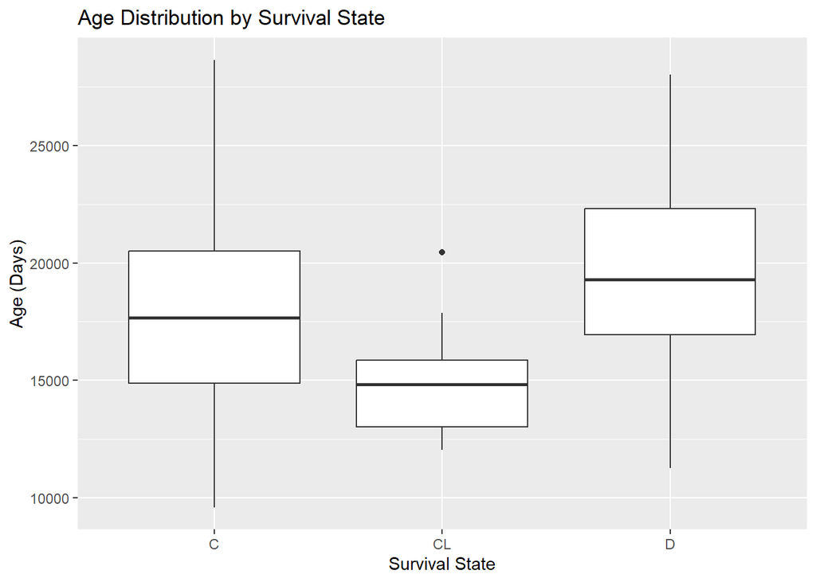

### More: Histograms of N_Days and Age

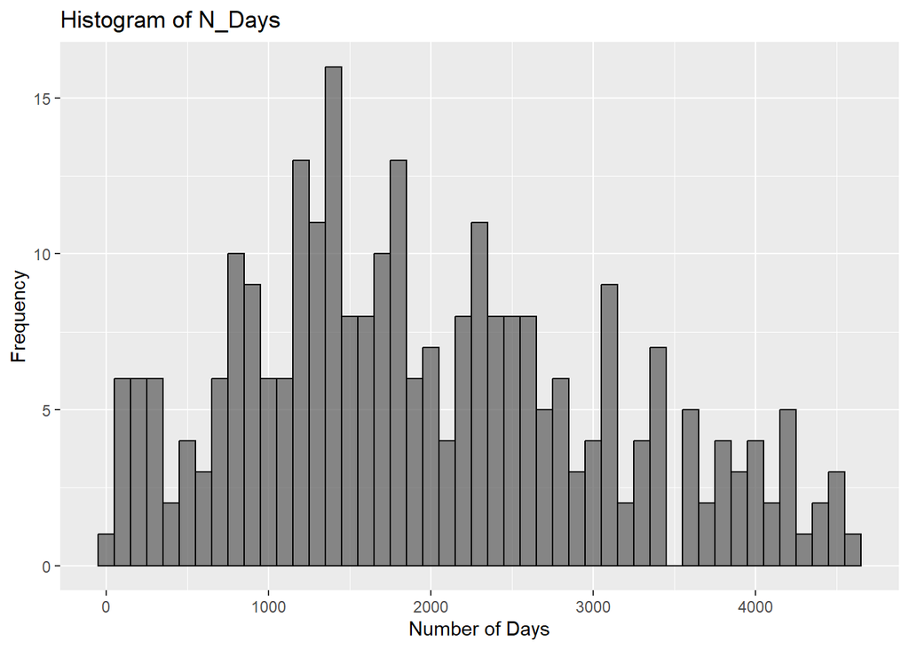

```r
HIST_N_Days = readRDS(here::here("outputs/plot_NDaysHIST.rds"))
HIST_N_Days
```

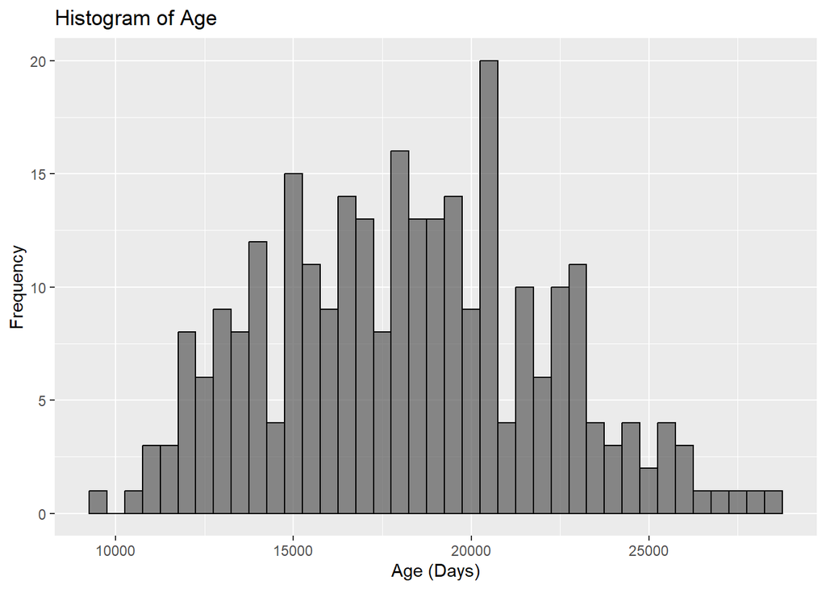

```r
HIST_Age = readRDS(here::here("outputs/plot_AgeHIST.rds"))
HIST_Age
```

### More: Kaplan-Meier (K-M) plot for overall survival and survival across treatment groups

We also want to check the overall survival of patients and survival by treatment, using K-M plots.

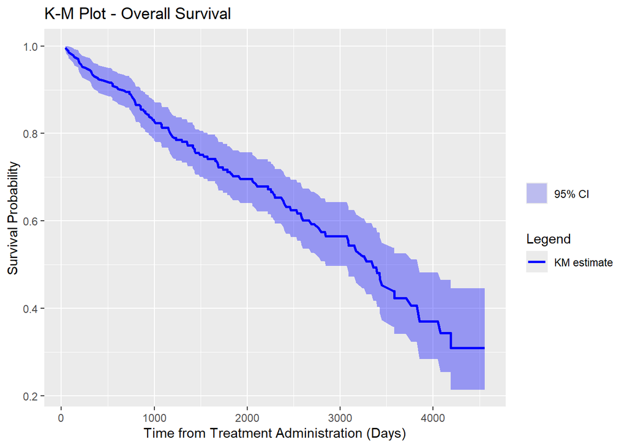

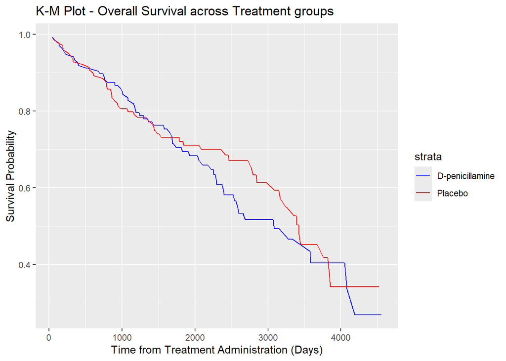

This initial analysis presents an overview of the Cirrhosis Prediction Dataset and provides some preliminary insights into patient demographics and outcomes. In subsequent analyses, we will further explore the relationships between different clinical features and their impact on survival and cirrhosis progression.